# Practical Machine Learning Project

# Variable Importance

“In every tree grown in the forest, put down the oob cases and count the number of votes cast for the correct class. Now randomly permute the values of variable m in the oob cases and put these cases down the tree. Subtract the number of votes for the correct class in the variable-m-permuted oob data from the number of votes for the correct class in the untouched oob data. The average of this number over all trees in the forest is the raw importance score for variable m.

If the values of this score from tree to tree are independent, then the standard error can be computed by a standard computation. The correlations of these scores between trees have been computed for a number of data sets and proved to be quite low, therefore we compute standard errors in the classical way, divide the raw score by its standard error to get a z-score, ands assign a significance level to the z-score assuming normality." Breiman.

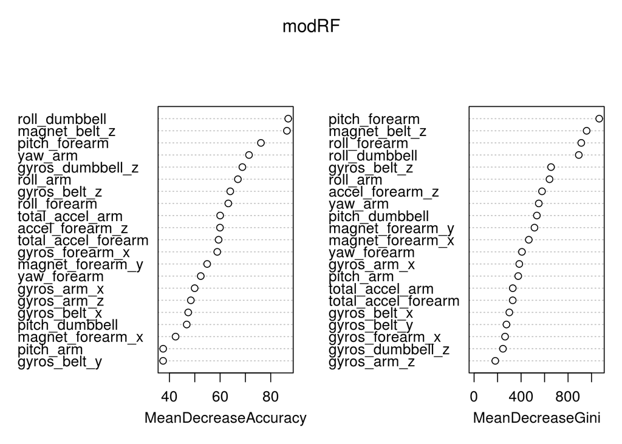

```r
varImpPlot(modRF)
```

```r
importance(modRF)
```

```
##                            A        B         C        D        E
## gyros_belt_x        30.87047 40.93696  39.37221 34.19763 37.02538
## gyros_belt_y        22.40996 31.38959  28.58436 35.40808 37.71655
## gyros_belt_z        41.77445 58.71690  50.86675 53.21513 54.00625
## magnet_belt_z       57.58687 71.14984  69.07704 76.69717 80.10814
## roll_arm            41.01010 60.84533  56.24583 63.92771 46.82913
## pitch_arm           25.47333 40.49119  40.85724 36.23892 27.81167
## yaw_arm             48.58386 63.40145  53.92979 57.55821 44.78245
## total_accel_arm     31.72527 49.65404  46.18258 48.12092 41.54937
## gyros_arm_x         33.17338 53.34127  43.23352 44.87174 37.13572
## gyros_arm_z         26.61501 32.52925  27.49372 26.28528 32.25443
## roll_dumbbell       54.90979 78.78782 111.25742 71.38669 66.51133
## pitch_dumbbell      32.05716 53.14336  53.14793 34.29926 41.27708
## gyros_dumbbell_z    37.61954 47.72076  44.84060 40.88327 40.55390
## roll_forearm        52.81903 51.70364  79.75946 57.41266 47.01670
## pitch_forearm       45.79841 68.03647  58.07290 80.13960 62.73486
## yaw_forearm         32.83866 49.83909  39.83418 39.48336 41.69436
## total_accel_forearm 38.30521 43.97119  52.27643 43.29254 45.50574
## gyros_forearm_x     30.64430 41.29149  43.11488 42.46003 39.22034
## accel_forearm_z     37.22625 48.19141  60.56353 50.93384 48.67783
## magnet_forearm_x    32.38640 39.50755  38.90048 39.77071 36.43881
## magnet_forearm_y    40.14037 46.63182  52.68629 43.90059 43.01067
##                     MeanDecreaseAccuracy MeanDecreaseGini
## gyros_belt_x                    47.41351         300.0352
## gyros_belt_y                    37.48504         275.5628
## gyros_belt_z                    64.01551         655.1629
## magnet_belt_z                   86.40274         958.2343
## roll_arm                        67.03575         642.1775
## pitch_arm                       37.51066         375.6480
## yaw_arm                         71.43010         550.7585
## total_accel_arm                 60.02518         329.2748
## gyros_arm_x                     49.95421         384.7613
## gyros_arm_z                     48.44819         180.3257
## roll_dumbbell                   86.91519         891.5791
## pitch_dumbbell                  46.82265         534.5231
## gyros_dumbbell_z                68.80424         245.7110
## roll_forearm                    63.24909         912.5850
## pitch_forearm                   76.13255        1065.4119
## yaw_forearm                     52.36625         407.3758
## total_accel_forearm             59.40714         328.8682
## gyros_forearm_x                 58.88146         263.7638
## accel_forearm_z                 59.96536         578.3046
## magnet_forearm_x                42.41821         465.7211
## magnet_forearm_y                54.88758         514.0480
```

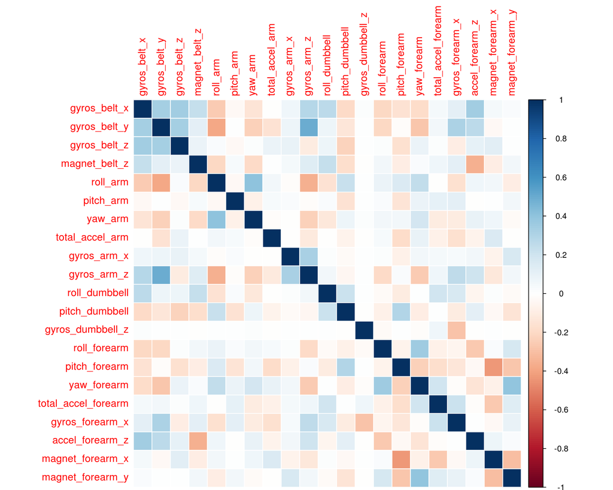

```r
library(corrplot)
M <- cor(trainData[, -length(names(trainData))])
corrplot(M, method = "color")
```

# Predictive Model - Support Vector Machine

```r
set.seed(133456)
trC <- trainControl(method="cv",number=5)
modSVM <- train(y~.,data=trainData,method="svmRadial", trControl = trC)
modSVM
```

```
## Support Vector Machines with Radial Basis Function Kernel
##
## 13737 samples
##    21 predictors
##     5 classes: 'A', 'B', 'C', 'D', 'E'
##
## No pre-processing
## Resampling: Cross-Validated (5 fold)
##
## Summary of sample sizes: 10991, 10989, 10990, 10988, 10990
##
## Resampling results across tuning parameters:
##
##   C     Accuracy   Kappa      Accuracy SD  Kappa SD
##   0.25  0.7832827  0.7252299  0.01766730   0.02239464
##   0.50  0.8254313  0.7784510  0.01669009   0.02120640
##   1.00  0.8630670  0.8262846  0.01554060   0.01976115
##
## Tuning parameter 'sigma' was held constant at a value of 0.03365271
## Accuracy was used to select the optimal model using  the largest value.
## The final values used for the model were sigma = 0.03365271 and C = 1.
```

```r
answerSVM <- predict(modSVM,test)

# Or use e1071 package
set.seed(325)
library(e1071)
svm.model <- svm(y ~., data = trainData)
svm.predTrain <- predict(svm.model, trainData[,-length(trainData)])
(accuracyTrainSVM <- mean(svm.predTrain == trainData$y))
```

```
## [1] 0.9177404
```

```r
svm.predTest <- predict(svm.model, testData[,-length(testData)])
(accuracyTestSVM <- mean(svm.predTest == testData$y))
```

```
## [1] 0.9009346
```

# Accuracy - Random Forest Model vs. Support Vector Machine Model

```r
cbind(accuracyTrainRF, accuracyTrainSVM)
```

```
##      accuracyTrainRF accuracyTrainSVM
## [1,]               1        0.9177404
```

```r
cbind(accuracyTestRF, accuracyTestSVM)
```

```
##      accuracyTestRF accuracyTestSVM
## [1,]      0.9819881       0.9009346
```